# Practical Machine Learning Project

Predict the manner people did the exercise

March 30, 2019

### Overview

The objective of this project is to use the data collected through wearable devices, such as Jawbone Up, Fitbit to monitor personal activities and predict how they perform the exercise.

The data we use in this analysis is from the source: http://web.archive.org/web/20161224072740/http:/groupware.les.inf.puc-rio.br/har. We use the training data to create our model and test data to evaluate the model performance.

### Data Exploration

First, we read in the data and explore the dataset to see the attributes, data type. We also take a look at the distributiont of our response variable (classe).

*Please see appendix for outputs*

```r
library(mlbench)
library(caret)
library(parallel)
library(iterators)
library(foreach)
library(doParallel)
library(corrplot)

training = read.csv('pml-training.csv',header=T)
testing = read.csv('pml-testing.csv',header=T)
head(training)
dim(training) # 19622 160
str(training)
```

```r
table(training$classe)
```

```
##
##    A    B    C    D    E
## 5580 3797 3422 3216 3607
```

### Data Pre-Processing

After viewing the data, we decided to convert factor variables to numeric variables and check missing data. We tranformed variables with missing values into indicators.

```r
training$kurtosis_roll_belt = as.numeric(as.character(training$kurtosis_roll_belt))
training$kurtosis_picth_belt = as.numeric(as.character(training$kurtosis_picth_belt))
training$skewness_roll_belt = as.numeric(as.character(training$skewness_roll_belt))
training$skewness_roll_belt.1 = as.numeric(as.character(training$skewness_roll_belt.1))
training$max_yaw_belt = as.numeric(as.character(training$max_yaw_belt))
training$min_yaw_belt = as.numeric(as.character(training$min_yaw_belt))
training$kurtosis_roll_arm = as.numeric(as.character(training$kurtosis_roll_arm))
training$kurtosis_picth_arm = as.numeric(as.character(training$kurtosis_picth_arm))
training$skewness_yaw_arm = as.numeric(as.character(training$skewness_yaw_arm))
training$kurtosis_roll_dumbbell = as.numeric(as.character(training$kurtosis_roll_dumbbell))
training$kurtosis_picth_dumbbell = as.numeric(as.character(training$kurtosis_picth_dumbbell))
training$max_yaw_dumbbell = as.numeric(as.character(training$max_yaw_dumbbell))
training$min_yaw_dumbbell = as.numeric(as.character(training$min_yaw_dumbbell))
training$kurtosis_roll_forearm = as.numeric(as.character(training$kurtosis_roll_forearm))
training$kurtosis_picth_forearm = as.numeric(as.character(training$kurtosis_picth_forearm))
training$max_yaw_forearm = as.numeric(as.character(training$max_yaw_forearm))
training$min_yaw_forearm = as.numeric(as.character(training$min_yaw_forearm))

missing_cnt = sapply(training,function(x) sum(is.na(x)))
table(missing_cnt)
```

```
## missing_cnt
##     0 19216 19218 19221 19225 19226 19227 19248 19294 19296 19300 19301
##    76    67     1     3     1     3     1     2     1     1     3     1
```

```r
for(col in names(training)){
  if(sum(is.na(training[,col]))>0)
    training[,col] = ifelse(is.na(training[,col]),0,1)
}
```

### Model Building

We split the data into training and testing set using 70/30 split. Excluded 4 variables that are not associated with our response variable. Then we calculated the correlation of all the variables and keep the top 30 variables that are relatively highly correlated with our response variable.

```r
set.seed(123)
idx = createDataPartition(training$classe,p=0.7,list=FALSE)
train = training[idx,]
test = training[-idx,]

yvar = as.numeric(train$classe)
xvar = train[,sapply(train,is.numeric)]
xvar = xvar[,-c(1,2,3,4)]

allvar = cbind(xvar,yvar)
m = abs(cor(allvar))
corr_df = data.frame(row=rownames(m)[row(m)[upper.tri(m)]],
                     col=colnames(m)[col(m)[upper.tri(m)]],
                     corr=m[upper.tri(m)])
corr_df_y = corr_df[which(corr_df$col=='yvar'),]
corr_df_y2 = corr_df_y[order(-corr_df_y$corr),]

# take top 30 variables that are most correlated with response

corr_df_y2[1:30,c(1)]
```

```
##  [1] pitch_forearm        magnet_arm_x         magnet_belt_y
##  [4] magnet_arm_y         accel_arm_x          accel_forearm_x
##  [7] magnet_forearm_x     magnet_belt_z        pitch_arm
## [10] magnet_arm_z         total_accel_forearm  magnet_dumbbell_z
## [13] total_accel_arm      accel_dumbbell_x     magnet_forearm_y
## [16] accel_arm_y          accel_belt_z         roll_arm
## [19] total_accel_belt     pitch_dumbbell       accel_dumbbell_z
## [22] roll_belt            magnet_dumbbell_x    total_accel_dumbbell
## [25] yaw_forearm          roll_dumbbell        yaw_arm
## [28] accel_arm_z          magnet_forearm_z     gyros_dumbbell_y
## 136 Levels: accel_arm_x accel_arm_y accel_arm_z ... yaw_forearm
```

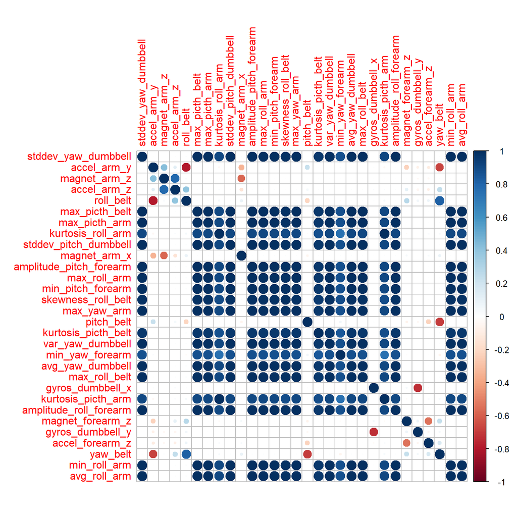

```r
corr_org = cor(allvar)
corrplot(corr_org[corr_df_y2[1:30,c(1)],corr_df_y2[1:30,c(1)]])
```

#### Random Forest

Use the top 30 variables we selected and create a random foreset model using 5-fold cross-validation. Then we apply the model to the testing set. The accurary for the testing set is 0.9867 so the **out-of-sample error is 0.0133**. We consider this as a decent model so we decided to use the model in our validation (test) set to predict the 20 new cases.

```r
cluster = makeCluster(detectCores() - 1)
registerDoParallel(cluster)
fitControl = trainControl(method = "cv", number = 5, allowParallel = TRUE)
rf_model = train(classe ~ pitch_forearm+magnet_arm_x+magnet_belt_y+magnet_arm_y+accel_arm_x+
                 accel_forearm_x+magnet_forearm_x+magnet_belt_z+pitch_arm+magnet_arm_z+
                 total_accel_forearm+magnet_dumbbell_z+total_accel_arm+accel_dumbbell_x+magnet_forearm_y+
                 accel_arm_y+accel_belt_z+roll_arm+total_accel_belt+pitch_dumbbell+
                 accel_dumbbell_z+roll_belt+magnet_dumbbell_x+total_accel_dumbbell+yaw_forearm+
                 roll_dumbbell+yaw_arm+accel_arm_z+magnet_forearm_z+gyros_dumbbell_y,
                 data=train, method="rf", trControl = fitControl)
print(rf_model)
```

```
## Random Forest
##
## 13737 samples
##    30 predictor
##     5 classes: 'A', 'B', 'C', 'D', 'E'
##
## No pre-processing
## Resampling: Cross-Validated (5 fold)
## Summary of sample sizes: 10989, 10991, 10989, 10990, 10989
## Resampling results across tuning parameters:
##
##   mtry  Accuracy   Kappa
##    2    0.9818732  0.9770669
##   16    0.9849310  0.9809383
##   30    0.9793256  0.9738426
##
## Accuracy was used to select the optimal model using the largest value.
## The final value used for the model was mtry = 16.
```

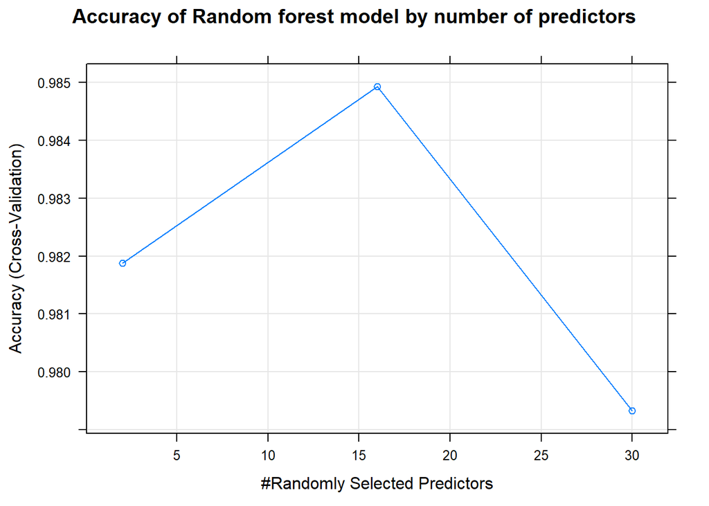

```r
plot(rf_model,main="Accuracy of Random forest model by number of predictors")
```

```r
test_pred = predict(rf_model,newdata=test)
confusionMatrix(test$classe,test_pred)
```

```
## Confusion Matrix and Statistics
##
##           Reference
## Prediction    A    B    C    D    E
##          A 1668    3    0    0    3
##          B   11 1122    6    0    0
##          C    0   19 1002    5    0
##          D    0    0   26  936    2
##          E    0    1    0    2 1079
##
## Overall Statistics
##
##                Accuracy : 0.9867
##                  95% CI : (0.9835, 0.9895)
##     No Information Rate : 0.2853
##     P-Value [Acc > NIR] : < 2.2e-16
##
##                   Kappa : 0.9832
##  Mcnemar's Test P-Value : NA
##
## Statistics by Class:
##
##                      Class: A Class: B Class: C Class: D Class: E
## Sensitivity            0.9934   0.9799   0.9691   0.9926   0.9954
## Specificity            0.9986   0.9964   0.9951   0.9943   0.9994
## Pos Pred Value         0.9964   0.9851   0.9766   0.9710   0.9972
## Neg Pred Value         0.9974   0.9952   0.9934   0.9986   0.9990
## Prevalence             0.2853   0.1946   0.1757   0.1602   0.1842
## Detection Rate         0.2834   0.1907   0.1703   0.1590   0.1833
## Detection Prevalence   0.2845   0.1935   0.1743   0.1638   0.1839
## Balanced Accuracy      0.9960   0.9882   0.9821   0.9935   0.9974
```

### Prediction for the Validation Data

Before we predict the test set, we applied the same transformation as training set: Convert factor variables to numeric variables and create missing indicators.

The prediction result on the validation set is 100% accurate.

```r
testing$kurtosis_roll_belt = as.numeric(as.character(testing$kurtosis_roll_belt))
testing$kurtosis_picth_belt = as.numeric(as.character(testing$kurtosis_picth_belt))
testing$skewness_roll_belt = as.numeric(as.character(testing$skewness_roll_belt))
testing$skewness_roll_belt.1 = as.numeric(as.character(testing$skewness_roll_belt.1))
testing$max_yaw_belt = as.numeric(as.character(testing$max_yaw_belt))
testing$min_yaw_belt = as.numeric(as.character(testing$min_yaw_belt))
testing$kurtosis_roll_arm = as.numeric(as.character(testing$kurtosis_roll_arm))
testing$kurtosis_picth_arm = as.numeric(as.character(testing$kurtosis_picth_arm))
testing$skewness_yaw_arm = as.numeric(as.character(testing$skewness_yaw_arm))
testing$kurtosis_roll_dumbbell = as.numeric(as.character(testing$kurtosis_roll_dumbbell))
testing$kurtosis_picth_dumbbell = as.numeric(as.character(testing$kurtosis_picth_dumbbell))
testing$max_yaw_dumbbell = as.numeric(as.character(testing$max_yaw_dumbbell))
testing$min_yaw_dumbbell = as.numeric(as.character(testing$min_yaw_dumbbell))
testing$kurtosis_roll_forearm = as.numeric(as.character(testing$kurtosis_roll_forearm))
testing$kurtosis_picth_forearm = as.numeric(as.character(testing$kurtosis_picth_forearm))
testing$max_yaw_forearm = as.numeric(as.character(testing$max_yaw_forearm))
testing$min_yaw_forearm = as.numeric(as.character(testing$min_yaw_forearm))
for(col in names(testing)){
  if(sum(is.na(testing[,col]))>0)
    testing[,col] = ifelse(is.na(testing[,col]),0,1)
}
```

```r
testing_pred = predict(rf_model,newdata=testing)
testing_pred
```

```
##  [1] B A B A A E D B A A B C B A E E A B B B
## Levels: A B C D E
```

```r
stopCluster(cluster)
registerDoSEQ()
```

### Appendix

```r
head(training)
```

```
##   X user_name raw_timestamp_part_1 raw_timestamp_part_2   cvtd_timestamp
## 1 1  carlitos           1323084231               788290 05/12/2011 11:23
## 2 2  carlitos           1323084231               808298 05/12/2011 11:23
## 3 3  carlitos           1323084231               820366 05/12/2011 11:23
## 4 4  carlitos           1323084232               120339 05/12/2011 11:23
## 5 5  carlitos           1323084232               196328 05/12/2011 11:23
## 6 6  carlitos           1323084232               304277 05/12/2011 11:23
##   new_window num_window roll_belt pitch_belt yaw_belt total_accel_belt
## 1         no         11      1.41       8.07    -94.4                3
## 2         no         11      1.41       8.07    -94.4                3
## 3         no         11      1.42       8.07    -94.4                3
## 4         no         12      1.48       8.05    -94.4                3
## 5         no         12      1.48       8.07    -94.4                3
## 6         no         12      1.45       8.06    -94.4                3
##   kurtosis_roll_belt kurtosis_picth_belt kurtosis_yaw_belt
```

[output cut: 265 more lines]

```r
dim(training)
```

```
## [1] 19622   160
```

```r
str(training)
```

```
## 'data.frame':    19622 obs. of  160 variables:
##  $ X                       : int  1 2 3 4 5 6 7 8 9 10 ...
##  $ user_name               : Factor w/ 6 levels "adelmo","carlitos",..: 2 2 2 2 2 2 2 2 2 2 ...
##  $ raw_timestamp_part_1    : int  1323084231 1323084231 1323084231 1323084232 1323084232 1323084232 1323084232 1323084232 1323084232 1323084232 ...
##  $ raw_timestamp_part_2    : int  788290 808298 820366 120339 196328 304277 368296 440390 484323 484434 ...
##  $ cvtd_timestamp          : Factor w/ 20 levels "02/12/2011 13:32",..: 9 9 9 9 9 9 9 9 9 9 ...
##  $ new_window              : Factor w/ 2 levels "no","yes": 1 1 1 1 1 1 1 1 1 1 ...
##  $ num_window              : int  11 11 11 12 12 12 12 12 12 12 ...
##  $ roll_belt               : num  1.41 1.41 1.42 1.48 1.48 1.45 1.42 1.42 1.43 1.45 ...
##  $ pitch_belt              : num  8.07 8.07 8.07 8.05 8.07 8.06 8.09 8.13 8.16 8.17 ...
##  $ yaw_belt                : num  -94.4 -94.4 -94.4 -94.4 -94.4 -94.4 -94.4 -94.4 -94.4 -94.4 ...
##  $ total_accel_belt        : int  3 3 3 3 3 3 3 3 3 3 ...
##  $ kurtosis_roll_belt      : num  0 0 0 0 0 0 0 0 0 0 ...
##  $ kurtosis_picth_belt     : num  0 0 0 0 0 0 0 0 0 0 ...
##  $ kurtosis_yaw_belt       : Factor w/ 2 levels "","#DIV/0!": 1 1 1 1 1 1 1 1 1 1 ...
```

[output cut: 86 more lines]